# FBI-Gun-Data-Exploration

## Introduction

### NICS Data (from the FBI's National Instant Criminal Background Check System):

> This dataset contains information on firearm checks conducted across different states in the U.S. It is structured by month and state, detailing the types of checks conducted and their counts.

#### Columns:

month: The month of the firearm check (e.g., "2017-09").

state: The state where the firearm check occurred.

permit: The number of permit checks.

permit_recheck: Number of rechecks on permits.

handgun, long_gun, other: Number of checks for handguns, long guns, and other types of firearms, respectively.

multiple: Checks involving multiple firearm types.

admin: Administrative checks.

prepawn_handgun, prepawn_long_gun, prepawn_other: Checks related to pawning firearms.

redemption_handgun, redemption_long_gun, redemption_other: Redemption checks for previously pawned firearms.

returned_handgun, returned_long_gun, returned_other: Checks for returned firearms.

rentals_handgun, rentals_long_gun: Checks related to rentals.

private_sale_handgun, private_sale_long_gun, private_sale_other: Checks for private sales. return_to_seller_handgun, return_to_seller_long_gun, return_to_seller_other: Checks for firearms returned to sellers.

totals: The total number of checks conducted in a given month for a state.

### U.S. Census Data (from census.gov):

> This dataset contains demographic and economic data for each state in the U.S., primarily for the year 2016.

#### Columns:

Fact: A description of the variable (e.g., population size, income levels).

Fact Note: Additional notes about the variable.

The remaining columns represent each state (e.g., Alabama, Alaska, etc.) with data values corresponding to the variable described in the Fact column.

### Relationship Between Tables

The NICS Data table provides monthly information about firearm background checks for each state, while the Census Data provides demographic and socioeconomic information for each state. These tables can be related using the state attribute in the NICS dataset and the state columns in the Census dataset, enabling state-level analysis of firearm checks in relation to demographic factors.

### Questions for Analysis

> In this report, the following questions will be explored to understand the patterns and trends in gun registrations and their relationship with census data across the United States:

#### 1. What census data is most associated with high gun per capita?

This question investigates which demographic or socioeconomic factors (e.g., population size, median income, education levels) are most strongly associated with the number of guns per capita in each state. This analysis will help identify the primary factors that correlate with high rates of gun ownership.

#### 2. Which states have had the highest growth in gun registrations?

This analysis focuses on identifying states with the most significant growth in gun registrations over a set period. Understanding which states are experiencing the most rapid increase in firearm ownership can provide insights into regional trends and factors influencing these changes.

#### 3. What is the overall trend of gun purchases?

This question examines the overall trend of gun purchases across the United States over time. By analyzing the data, the goal is to identify patterns such as seasonality, spikes in purchases, or overall growth or decline in firearm acquisitions.

These questions will guide the analysis to provide a comprehensive view of firearm registration trends in relation to demographic and economic data. The answers to these questions will help illustrate the relationship between socioeconomic factors and firearm ownership patterns.

> **Tip**: Welcome to the Investigate a Dataset project! You will find tips in quoted sections like this to help organize your approach to your investigation. Once you complete this project, remove these **Tip** sections from your report before submission. First things first, you might want to double-click this Markdown cell and change the title so that it reflects your dataset and investigation.

# Project: Investigate a Dataset - FBI Gun Data

- Introduction
- Data Wrangling
- Exploratory Data Analysis
- Conclusions

## Data Wrangling

### General Properties

```python
# Essential packages for data analysis and visualization
import pandas as pd
import numpy as np
import matplotlib.pyplot as plt
import seaborn as sns

# Ensure plots appear inline in the Jupyter Notebook
%matplotlib inline

# Importing additional statistical functions
from scipy import stats

# Load the NICS data
nics_data = pd.read_csv('.../project_investigate a dataset/gun_data.csv')

# Display the first few rows of the NICS dataset
nics_data.head()

# Load the Census data
census_data = pd.read_csv('...project_investigate a dataset/US_Census_Data.csv')

# Display the first few rows of the Census dataset
census_data.head()
```

|  | Fact | Fact Note | Alabama | Alaska | Arizona | Arkansas | California | Colorado | Connecticut | Delaware | ... | South Dakota | Tennessee | Texas | Utah | Vermont | Virginia | Washington | West Virginia | Wisconsin | Wyoming |
| --- | --- | --- | --- | --- | --- | --- | --- | --- | --- | --- | --- | --- | --- | --- | --- | --- | --- | --- | --- | --- | --- |
| 0 | Population estimates, July 1, 2016, (V2016) | NaN | 4,863,300 | 741,894 | 6,931,071 | 2,988,248 | 39,250,017 | 5,540,545 | 3,576,452 | 952,065 | ... | 865454 | 6651194 | 27,862,596 | 3,051,217 | 624,594 | 8,411,808 | 7,288,000 | 1,831,102 | 5,778,708 | 585,501 |
| 1 | Population estimates base, April 1, 2010, (V2... | NaN | 4,780,131 | 710,249 | 6,392,301 | 2,916,025 | 37,254,522 | 5,029,324 | 3,574,114 | 897,936 | ... | 814195 | 6346298 | 25,146,100 | 2,763,888 | 625,741 | 8,001,041 | 6,724,545 | 1,853,011 | 5,687,289 | 563,767 |
| 2 | Population, percent change - April 1, 2010 (es... | NaN | 1.70% | 4.50% | 8.40% | 2.50% | 5.40% | 10.20% | 0.10% | 6.00% | ... | 0.063 | 0.048 | 10.80% | 10.40% | -0.20% | 5.10% | 8.40% | -1.20% | 1.60% | 3.90% |
| 3 | Population, Census, April 1, 2010 | NaN | 4,779,736 | 710,231 | 6,392,017 | 2,915,918 | 37,253,956 | 5,029,196 | 3,574,097 | 897,934 | ... | 814180 | 6346105 | 25,145,561 | 2,763,885 | 625,741 | 8,001,024 | 6,724,540 | 1,852,994 | 5,686,986 | 563,626 |
| 4 | Persons under 5 years, percent, July 1, 2016, ... | NaN | 6.00% | 7.30% | 6.30% | 6.40% | 6.30% | 6.10% | 5.20% | 5.80% | ... | 0.071 | 0.061 | 7.20% | 8.30% | 4.90% | 6.10% | 6.20% | 5.50% | 5.80% | 6.50% |

5 rows × 52 columns

### Data Cleaning

#### Data Structure Overview

##### NICS Dataset:

This data contains 27 columns, including: month (string): The month and year of firearm checks. state (string): The state where the checks were conducted. Various columns for different types of firearm checks (e.g., handgun, long_gun, permit). Aggregate columns like totals showing the total checks per month per state.

###### Potential Problems:

Missing values in several columns (e.g., permit_recheck, other, returned_*). Inconsistent data types (e.g., some numeric columns might have been read as strings if they contained errors). Duplicate rows or columns with little variation.

#### Census Dataset:

This datancontains 52 columns, including: Fact (string): Descriptions of different demographic and economic factors. Fact Note (string): Notes providing additional information on the Fact. Columns for each state containing values related to the demographic/economic factor.

###### Potential Problems:

Missing values in Fact and Fact Note. Data in state columns may contain inconsistent formats (e.g., percentages stored as strings). Some entries may not be relevant to the analysis (e.g., demographic data unrelated to firearm ownership).

### Data Cleaning Steps

#### NICS Dataset:

- Drop columns with excessive missing values: Columns like permit_recheck, other, and returned_* may not provide sufficient information due to high missing values.
- Fill missing values in remaining columns: Use median values for numeric columns to fill remaining gaps.
- Convert data types: Ensure all numeric columns are appropriately set as float or int types.
- Remove duplicate rows: Check for and remove any duplicate entries.

#### Census Dataset:

```python
# Code for NICS Dataset Cleaning

# Dropping columns with excessive missing values
columns_to_drop_nics = ['permit_recheck', 'other', 'returned_handgun', 'returned_long_gun', 'returned_other']
nics_cleaned = nics_data.drop(columns=columns_to_drop_nics)

# Filling missing values in the remaining numeric columns using the median
nics_cleaned.fillna(nics_cleaned.median(numeric_only=True), inplace=True)

# Ensuring all numeric columns are properly typed
for column in nics_cleaned.columns[2:]:  # Excluding 'month' and 'state' which are non-numeric
    nics_cleaned[column] = pd.to_numeric(nics_cleaned[column], errors='coerce')

# Dropping any duplicate rows if they exist
nics_cleaned.drop_duplicates(inplace=True)

# Display the cleaned NICS dataset
nics_cleaned.head()
```

|  | month | state | permit | handgun | long_gun | multiple | admin | prepawn_handgun | prepawn_long_gun | prepawn_other | ... | redemption_other | rentals_handgun | rentals_long_gun | private_sale_handgun | private_sale_long_gun | private_sale_other | return_to_seller_handgun | return_to_seller_long_gun | return_to_seller_other | totals |
| --- | --- | --- | --- | --- | --- | --- | --- | --- | --- | --- | --- | --- | --- | --- | --- | --- | --- | --- | --- | --- | --- |
| 0 | 2017-09 | Alabama | 16717.0 | 5734.0 | 6320.0 | 317 | 0.0 | 15.0 | 21.0 | 2.0 | ... | 1.0 | 0.0 | 0.0 | 9.0 | 16.0 | 3.0 | 0.0 | 0.0 | 3.0 | 32019 |
| 1 | 2017-09 | Alaska | 209.0 | 2320.0 | 2930.0 | 160 | 0.0 | 5.0 | 2.0 | 0.0 | ... | 2.0 | 0.0 | 0.0 | 17.0 | 24.0 | 1.0 | 0.0 | 0.0 | 0.0 | 6303 |
| 2 | 2017-09 | Arizona | 5069.0 | 11063.0 | 7946.0 | 631 | 0.0 | 13.0 | 6.0 | 0.0 | ... | 3.0 | 0.0 | 0.0 | 38.0 | 12.0 | 2.0 | 0.0 | 0.0 | 0.0 | 28394 |
| 3 | 2017-09 | Arkansas | 2935.0 | 4347.0 | 6063.0 | 366 | 51.0 | 12.0 | 13.0 | 0.0 | ... | 4.0 | 0.0 | 0.0 | 13.0 | 23.0 | 0.0 | 0.0 | 2.0 | 1.0 | 17747 |
| 4 | 2017-09 | California | 57839.0 | 37165.0 | 24581.0 | 0 | 0.0 | 0.0 | 0.0 | 0.0 | ... | 5.0 | 0.0 | 0.0 | 0.0 | 0.0 | 0.0 | 0.0 | 0.0 | 0.0 | 123506 |

5 rows × 22 columns

```python
# Census Dataset Cleaning Code

# Dropping rows where 'Fact' is missing as these are essential identifiers
census_cleaned = census_data.dropna(subset=['Fact']).copy()

# Filling missing values in the 'Fact Note' column with empty strings using .loc
census_cleaned.loc[:, 'Fact Note'] = census_cleaned['Fact Note'].fillna('')

# Removing commas and converting values to numeric where possible using the recommended approach
for state_col in census_cleaned.columns[2:]:
    # Removing commas
    census_cleaned[state_col] = census_cleaned[state_col].replace({',': ''}, regex=True)
    # Removing percentage signs and dividing by 100
    census_cleaned[state_col] = census_cleaned[state_col].replace({'%': ''}, regex=True)
    # Converting to numeric using the recommended approach
    census_cleaned[state_col] = pd.to_numeric(census_cleaned[state_col], errors='coerce')

# Filtering rows that are relevant to population, income, and unemployment
relevant_facts = ['Population', 'Income', 'Unemployment']
census_cleaned = census_cleaned[census_cleaned['Fact'].str.contains('|'.join(relevant_facts), case=False, na=False)]

# Display the cleaned Census dataset
census_cleaned.head()
```

|  | Fact | Fact Note | Alabama | Alaska | Arizona | Arkansas | California | Colorado | Connecticut | Delaware | ... | South Dakota | Tennessee | Texas | Utah | Vermont | Virginia | Washington | West Virginia | Wisconsin | Wyoming |
| --- | --- | --- | --- | --- | --- | --- | --- | --- | --- | --- | --- | --- | --- | --- | --- | --- | --- | --- | --- | --- | --- |
| 0 | Population estimates, July 1, 2016, (V2016) |  | 4863300.0 | 741894.0 | 6931071.0 | 2988248.0 | 39250017.0 | 5540545.0 | 3576452.0 | 952065.0 | ... | 865454.000 | 6651194.000 | 27862596.0 | 3051217.0 | 624594.0 | 8411808.0 | 7288000.0 | 1831102.0 | 5778708.0 | 585501.0 |
| 1 | Population estimates base, April 1, 2010, (V2... |  | 4780131.0 | 710249.0 | 6392301.0 | 2916025.0 | 37254522.0 | 5029324.0 | 3574114.0 | 897936.0 | ... | 814195.000 | 6346298.000 | 25146100.0 | 2763888.0 | 625741.0 | 8001041.0 | 6724545.0 | 1853011.0 | 5687289.0 | 563767.0 |
| 2 | Population, percent change - April 1, 2010 (es... |  | 1.7 | 4.5 | 8.4 | 2.5 | 5.4 | 10.2 | 0.1 | 6.0 | ... | 0.063 | 0.048 | 10.8 | 10.4 | -0.2 | 5.1 | 8.4 | -1.2 | 1.6 | 3.9 |
| 3 | Population, Census, April 1, 2010 |  | 4779736.0 | 710231.0 | 6392017.0 | 2915918.0 | 37253956.0 | 5029196.0 | 3574097.0 | 897934.0 | ... | 814180.000 | 6346105.000 | 25145561.0 | 2763885.0 | 625741.0 | 8001024.0 | 6724540.0 | 1852994.0 | 5686986.0 | 563626.0 |
| 38 | In civilian labor force, total, percent of pop... |  | 58.0 | 67.7 | 59.3 | 58.5 | 63.1 | 67.6 | 67.2 | 63.1 | ... | 0.686 | 0.610 | 64.3 | 67.7 | 66.6 | 64.7 | 63.5 | 53.9 | 67.1 | 67.7 |

5 rows × 52 columns

## Exploratory Data Analysis

> **Tip**: Now that you've trimmed and cleaned your data, you're ready to move on to exploration. **Compute statistics** and **create visualizations** with the goal of addressing the research questions that you posed in the Introduction section. You should compute the relevant statistics throughout the analysis when an inference is made about the data. Note that at least two or more kinds of plots should be created as part of the exploration, and you must compare and show trends in the varied visualizations. Remember to utilize the visualizations that the pandas library already has available.

> **Tip**: Investigate the stated question(s) from multiple angles. It is recommended that you be systematic with your approach. Look at one variable at a time, and then follow it up by looking at relationships between variables. You should explore at least three variables in relation to the primary question. This can be an exploratory relationship between three variables of interest, or looking at how two independent variables relate to a single dependent variable of interest. Lastly, you should perform both single-variable (1d) and multiple-variable (2d) explorations.

### Research Question 1: How does the distribution of gun registrations vary by State

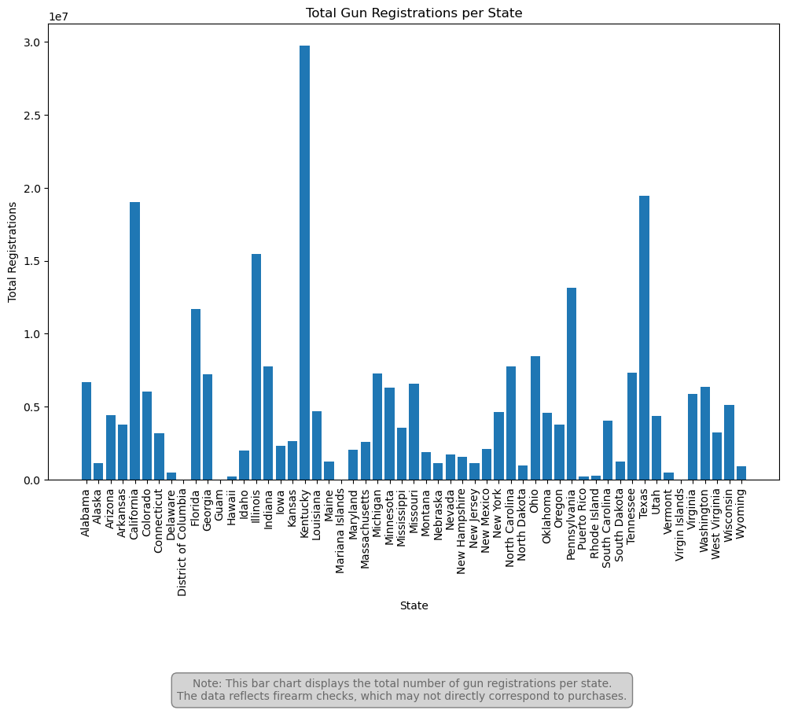

```
Mean: 4902229.781818182
Median: 3576312.0
Min: 462
Max: 29762434
Standard Deviation: 5606926.8443816025
```

```python
# Step 1: Calculate total gun registrations per state
state_totals = nics_data.groupby('state')['totals'].sum().reset_index()

# Step 2: Plot the distribution using a bar chart
plt.figure(figsize=(12, 10))
plt.bar(state_totals['state'], state_totals['totals'])
plt.xticks(rotation=90)

# Set the title and axis labels
plt.title('Total Gun Registrations per State')
plt.xlabel('State')
plt.ylabel('Total Registrations')

# Step 3: Adjust the subplot parameters to add space for the note box
plt.subplots_adjust(bottom=0.3)

# Step 4: Add a note box below the plot using plt.figtext
note_text = ("Note: This bar chart displays the total number of gun registrations per state.\n"
             "The data reflects firearm checks, which may not directly correspond to purchases.")
plt.figtext(0.5, 0.02, note_text, fontsize=10, color='dimgray', ha='center',
            bbox=dict(boxstyle='round,pad=0.5', edgecolor='gray', facecolor='lightgray'))

# Display the plot
plt.show()

# Step 5: Summary statistics
mean_registrations = state_totals['totals'].mean()
median_registrations = state_totals['totals'].median()
min_registrations = state_totals['totals'].min()
max_registrations = state_totals['totals'].max()
std_dev_registrations = state_totals['totals'].std()

# Print summary statistics
print(f"Mean: {mean_registrations}")
print(f"Median: {median_registrations}")
print(f"Min: {min_registrations}")
print(f"Max: {max_registrations}")
print(f"Standard Deviation: {std_dev_registrations}")
```

#### Results: The main insight from this plot is the variation in gun registrations across different states, highlighting that some states have significantly higher totals than others. This variation may reflect differences in population size, gun ownership rates, and state-level regulations or practices regarding firearm checks.

### Research Question 2 : What census data is most associated with high gun per capita?

```
The feature most associated with guns per capita is 'totals' with a correlation of 0.54.
```

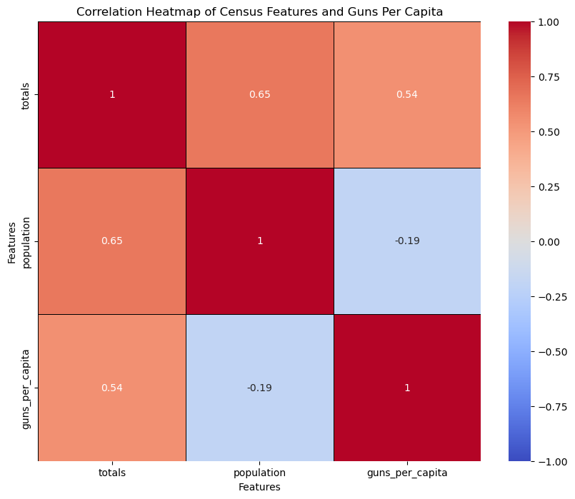

```python
import pandas as pd
import matplotlib.pyplot as plt
import seaborn as sns

def titles(title, xVar, yVar):
    """
    Set the title and labels for a plot.

    Parameters:
        title (str): The title of the plot.
        xVar (str): The label for the x-axis.
        yVar (str): The label for the y-axis.
    """
    plt.title(title)
    plt.xlabel(xVar)
    plt.ylabel(yVar)

# Extract population data from census_cleaned
census_population = census_cleaned[census_cleaned['Fact'] == 'Population estimates, July 1, 2016,  (V2016)'].iloc[:, 2:].T
census_population.columns = ['population']
census_population.index.name = 'state'
census_population.reset_index(inplace=True)

# Calculate total gun registrations per state from nics_cleaned
nics_state_totals = nics_cleaned.groupby('state')['totals'].sum().reset_index()

# Merge gun registrations with population data
merged_data = pd.merge(nics_state_totals, census_population, on='state')

# Calculate guns per capita and add as a new column
merged_data['guns_per_capita'] = merged_data['totals'] / merged_data['population']

# Step 1: Calculate the correlation matrix
corr_matrix = merged_data.corr(numeric_only=True)

# Step 2: Identify the feature most associated with 'guns_per_capita'
correlations_with_guns = corr_matrix['guns_per_capita'].drop('guns_per_capita')

# Find the feature with the highest absolute correlation value
most_associated_feature = correlations_with_guns.abs().idxmax()
highest_correlation_value = correlations_with_guns[most_associated_feature]

# Output the feature and correlation
result_text = (f"The feature most associated with guns per capita is '{most_associated_feature}' "
               f"with a correlation of {highest_correlation_value:.2f}.")
print(result_text)

# Step 3: Plot the heatmap directly
plt.figure(figsize=(10, 8))
sns.heatmap(corr_matrix, annot=True, cmap='coolwarm', linewidths=0.5, linecolor='black', vmin=-1, vmax=1)

# Step 4: Use the titles function to set the title and labels
titles('Correlation Heatmap of Census Features and Guns Per Capita', 'Features', 'Features')

# Step 5: Show the plot
plt.show()
```

### Research Question 3 : Which states have had the highest growth in gun registrations?

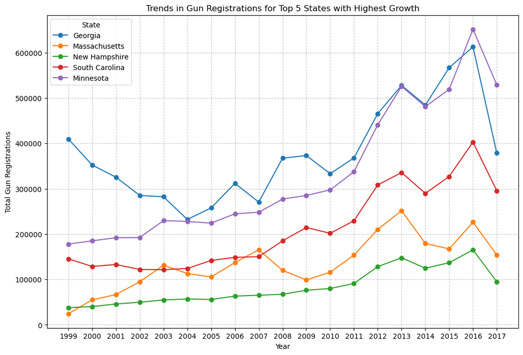

|  | state | growth |
| --- | --- | --- |
| 10 | Georgia | 560.659273 |
| 21 | Massachusetts | 98.530901 |
| 29 | New Hampshire | 82.399350 |
| 40 | South Carolina | 79.600707 |
| 23 | Minnesota | 78.549758 |

```python
import pandas as pd
import numpy as np
import matplotlib.pyplot as plt

# Step 1: Load and preprocess the NICS data from the specified directory
nics_data = pd.read_csv('.../project_investigate a dataset/gun_data.csv')

# Convert 'month' to datetime and extract 'year'
nics_data['month'] = pd.to_datetime(nics_data['month'], errors='coerce')
nics_data = nics_data.dropna(subset=['month'])  # Drop invalid rows
nics_data['year'] = nics_data['month'].dt.year

# Retain necessary columns and drop rows with zero or missing totals
nics_data_cleaned = nics_data[['state', 'year', 'totals']].dropna()
nics_data_cleaned = nics_data_cleaned[nics_data_cleaned['totals'] > 0]

# Step 2: Group by state and year, then calculate the annual totals
state_yearly_totals = nics_data_cleaned.groupby(['state', 'year'])['totals'].sum().reset_index()

# Step 3: Calculate the year-over-year percentage growth
state_yearly_totals['growth'] = state_yearly_totals.groupby('state')['totals'].pct_change() * 100

# Filter out rows with missing or infinite growth values
state_yearly_totals = state_yearly_totals.dropna(subset=['growth'])
state_yearly_totals = state_yearly_totals[~np.isinf(state_yearly_totals['growth'])]

# Filter out states with no variation in totals
variation_by_state = state_yearly_totals.groupby('state')['totals'].std()
valid_states = variation_by_state[variation_by_state > 0].index  # Keep states with variation
state_yearly_totals = state_yearly_totals[state_yearly_totals['state'].isin(valid_states)]

# Step 4: Exclude territories and calculate the average growth by state
excluded_territories = ['Virgin Islands', 'Mariana Islands', 'Guam', 'Puerto Rico', 'American Samoa']
state_yearly_totals = state_yearly_totals[~state_yearly_totals['state'].isin(excluded_territories)]

# Calculate the average growth for states only
average_growth_by_state = state_yearly_totals.groupby('state')['growth'].mean().reset_index()
average_growth_by_state = average_growth_by_state.sort_values(by='growth', ascending=False)

# Display the top 5 states with the highest growth in gun registrations
top_5_states = average_growth_by_state.head(5)

# Visualization: Trends for the top 5 states with formatted x-axis ticks
plt.figure(figsize=(12, 8))
top_states = top_5_states['state'].tolist()

for state in top_states:
    state_data = state_yearly_totals[state_yearly_totals['state'] == state]
    plt.plot(state_data['year'], state_data['totals'], marker='o', label=state)

# Add labels, title, and legend
plt.title('Trends in Gun Registrations for Top 5 States with Highest Growth')
plt.xlabel('Year')
plt.ylabel('Total Gun Registrations')
plt.legend(title='State')
plt.grid(True, linestyle='--', alpha=0.7)

# Format x-axis ticks as integers
plt.xticks(ticks=state_yearly_totals['year'].unique(), labels=state_yearly_totals['year'].unique().astype(int))

plt.show()

# Output top 5 states with their growth rates
top_5_states
```

### Research Question 4 : What is the overall trend of gun purchases?

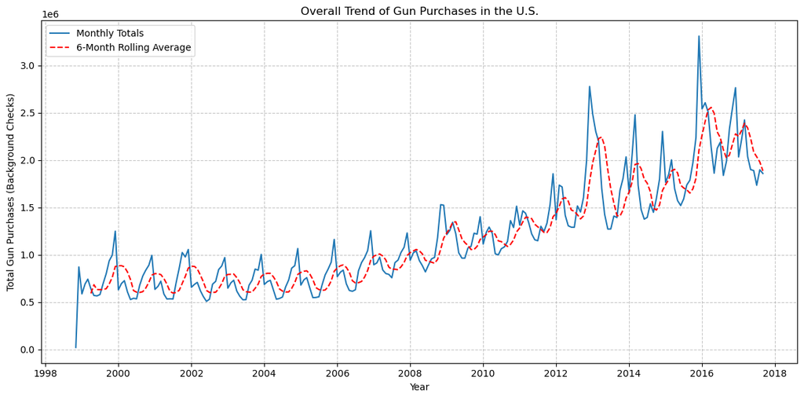

```python
# Step 1: Convert the 'month' column to datetime format
nics_cleaned['month'] = pd.to_datetime(nics_cleaned['month'])

# Step 2: Aggregate the total checks by month across all states
monthly_totals = nics_cleaned.groupby('month')['totals'].sum().reset_index()

# Step 3: Plot the overall trend of gun purchases
plt.figure(figsize=(12, 6))
plt.plot(monthly_totals['month'], monthly_totals['totals'], label='Monthly Totals')

# Calculate and plot a 6-month rolling average for smoothing
monthly_totals['6_month_avg'] = monthly_totals['totals'].rolling(window=6).mean()
plt.plot(monthly_totals['month'], monthly_totals['6_month_avg'], color='red', linestyle='--', label='6-Month Rolling Average')

plt.title('Overall Trend of Gun Purchases in the U.S.')
plt.xlabel('Year')
plt.ylabel('Total Gun Purchases (Background Checks)')
plt.legend()
plt.grid(True, linestyle='--', alpha=0.7)
plt.tight_layout()
plt.show()
```

#### The plot shows that the total number of gun purchases (as indicated by background checks) has generally increased over the years.

The overall trend indicates that gun purchases have been rising in the U.S., with periodic spikes possibly driven by external events. The rolling average confirms the long-term increase, smoothing out short-term variations.

## Conclusions

One limitation of this analysis is that it relies on the assumption that firearm background checks directly correlate with gun purchases. However, background checks may be conducted for other reasons (e.g., permit renewals), and not all background checks result in a gun purchase. This could potentially affect the accuracy of using background check data as a proxy for actual gun ownership rates and growth patterns.